[figure not shown]

[figure not shown]

[figure not shown]

# Intro

## Issue

In order to simulate sylviculture with TROLL we need to implement a new sylviculture module inside TROLL model code. A first litterature review was completed by an interview with Laurent Descroix of the Office Nationale des Forêts. We discovered that rotten trees were not random and seemed to depend both on tree species and diameter. This document presents modelling of relation between rotten trees and their species and diameter.

In fact we have two different questions:

- Predict if a tree will be probed as rotten (models **M**, see rotten 2)
- Predict how much of tree volume is rotten (models **N**, see rotten 3)

Table 2: Models summary.

| N | Model |
| --- | --- |
| $N_{0}$ | $V_f \sim \mathcal{N} (\beta_0 + \beta_1*dbh^2, \sigma*dbh)$ |

We tested models N detailed in following tabs to find the better trade-off between:

1. Complexity (and number of parameters)
2. Convergence
3. Likelihood

## Graph

### Trees estimated dbh and final softwood product.

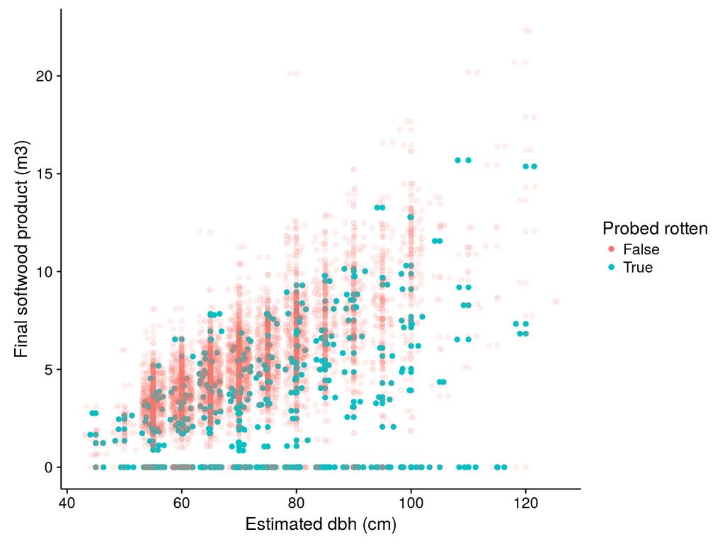

# $N_{0}$

## Model

> $N_{0}$: $V_f \sim \mathcal{N} (\beta_0 + \beta_1*dbh^2, \sigma*dbh)$

### Model Predictions.

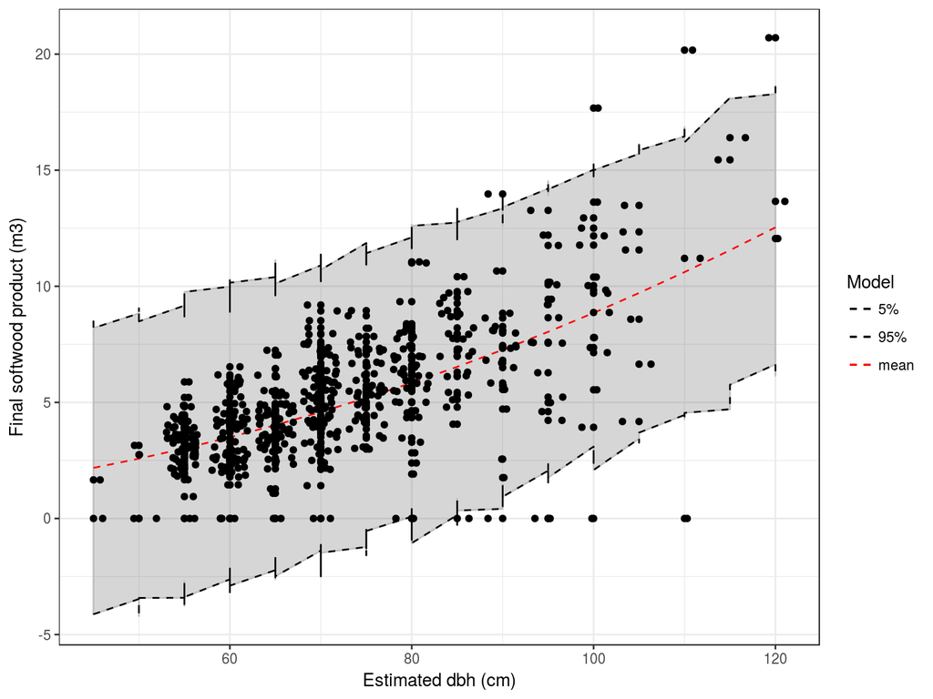

[figure not shown]

## Convergence

### Parameters posterior ditribution. *Light blue area represents 80% confidence interval, and vertical blue line the mean.*

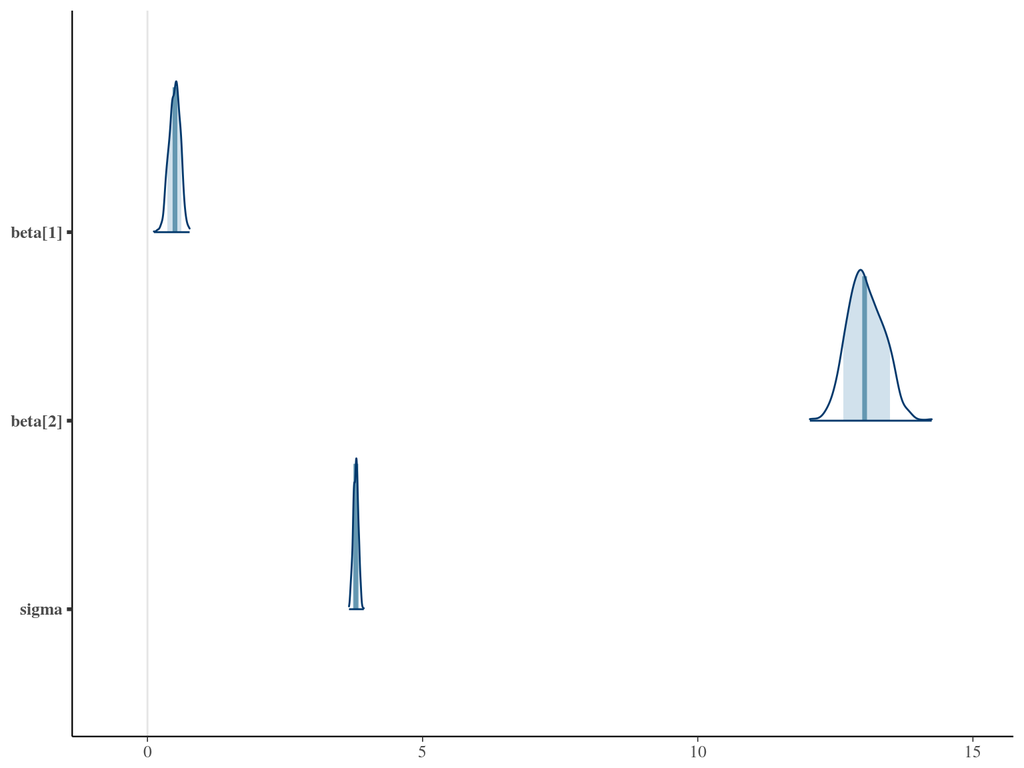

### Parameters pairs plot. *Parameters density distribution, pairs plot and Pearson’s coefficient of correlation.*

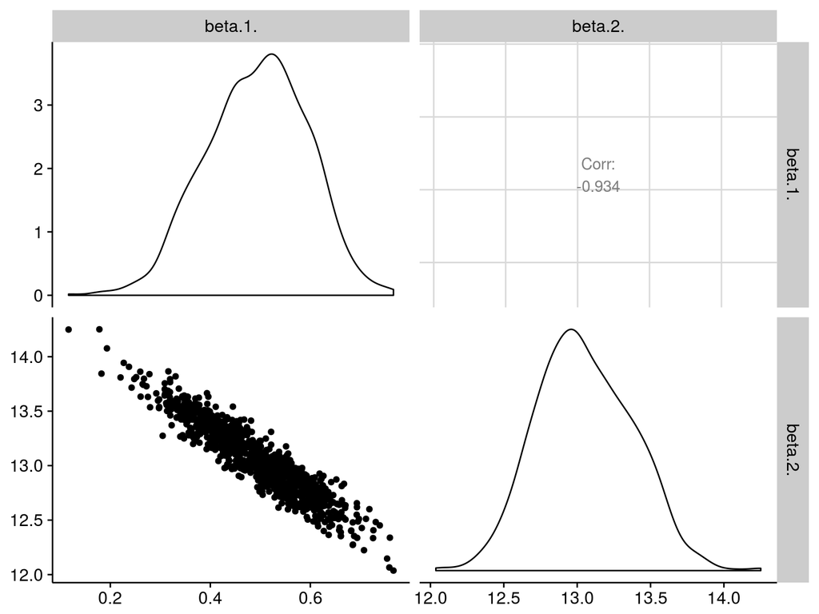